# TITLE by Rodrigo P Maruyama

## Pricipal component analysis - PCA

To better understand how the features are correlated I ran a PCA algorithm and I did the plot for the PCA Components and a graphic with Variance x Number of Component to decide how many Components I will use in the following models.

```r
# PCA
wdf.pca <- prcomp(wdf[,1:11], center = TRUE, scale. = TRUE)
```

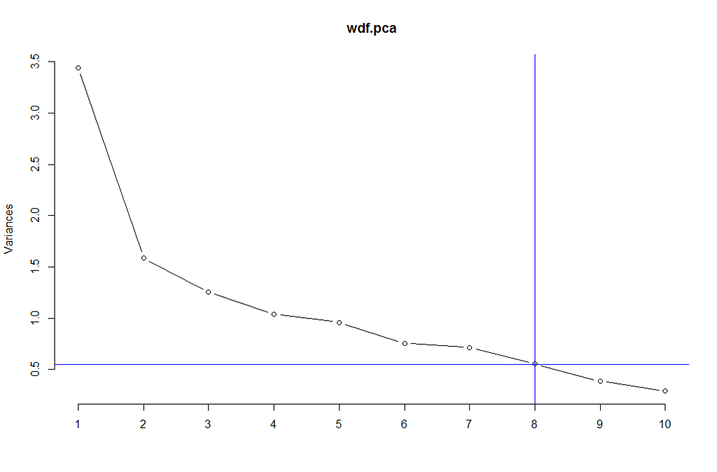

PCA Variance

```r
# Variance plot
plot(wdf.pca, type = "l")
abline(h=0.55, v=8, col="blue")

# PCA components plots
g <- autoplot(wdf.pca, loadings = TRUE, loadings.colour = 'blue', loadings.label = TRUE, loadings.label.size = 5, alpha = 0.3, main = 'PCA')
ggsave(file = 'pictures/pca_outliers.png', g)
```

Looking at this graphic it is easy to indentify that we can run the models with 8 components without loosing accuracy in our model.

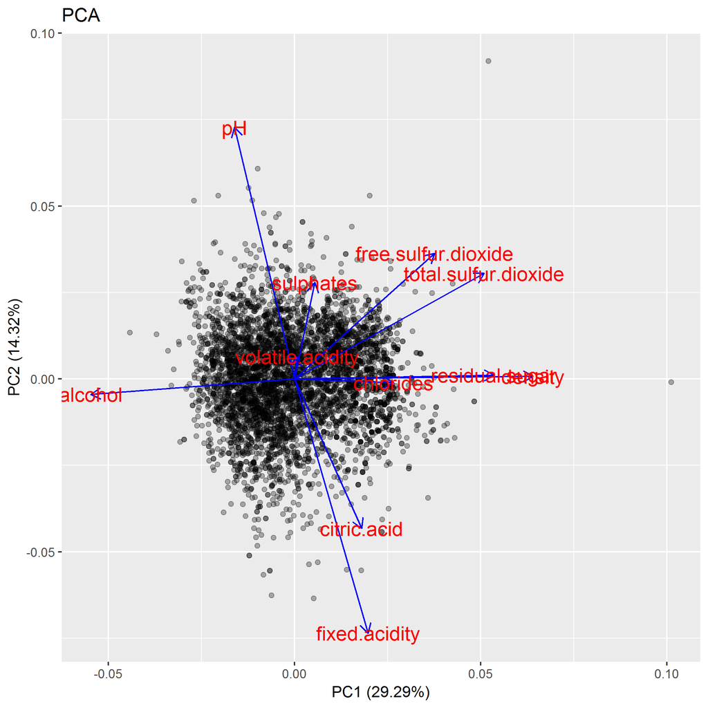

PCA components

In this graphic we can confirm some teories about the correlation between the variables. For example we expect negative correlation with alcohol and residual.sugar once the alcohol needs sugar to be produced. pH and citric.acid and fixed.acidity also need to have negative correlation once the lowest pH means very acid solution.

## New PCA Datasets

```r
# New dataframe
new_wdf.pca <- data.frame(wdf.pca$x)
new_wdf.pca <- data.frame(new_wdf.pca[,1:8], quality = wdf$quality)

# Creating train and test datasets
set.seed(123)
samp <- sample(nrow(wdf), 0.8 * nrow(wdf))
train.pca <- new_wdf.pca[samp, ]
test.pca <- new_wdf.pca[-samp, ]
```

## Random Forest Model after PCA

```r
# Random Forest
model <- randomForest(quality ~ . - quality, data = train.pca)
rf.pred <- predict(model, newdata = test.pca)
table(rf.pred, test.pca$quality)
```

```
##
## rf.pred   3   4   5   6   7   8   9
##       3   0   0   0   0   0   0   0
##       4   0   5   3   0   0   0   0
##       5   1  16 190  45   5   0   0
##       6   2  20 104 361  82  18   0
##       7   0   0   4  21  84   5   0
##       8   0   0   0   0   0  14   0
##       9   0   0   0   0   0   0   0
```

```r
classAgreement(table(rf.pred, test.pca$quality))
```

```
## $diag
## [1] 0.6673469
##
## $kappa
## [1] 0.4780199
##
## $rand
## [1] 0.6460612
##
## $crand
## [1] 0.2600683
```

```r
acc.rf.pca <- classAgreement(table(rf.pred, test.pca$quality))[1]
time <- Sys.time()
str <- paste('rf.pca', time, as.numeric(acc.rf.pca), sep = ',')
write(str, file = 'data/accuracy_models.csv', append = TRUE)
```

## Supported Vector Machines PCA

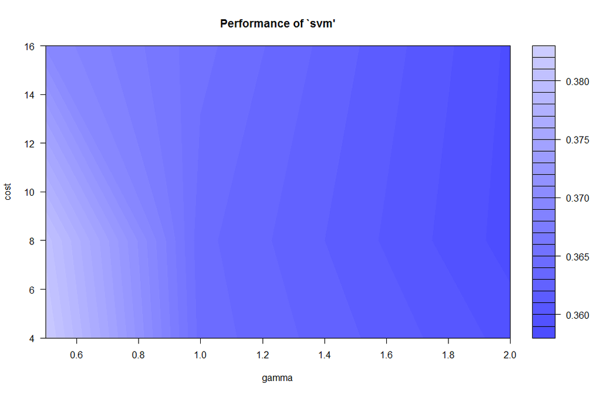

SVM tuning with PCA

```r
# Tune parameters for new dataset
obj <- tune.svm(quality~., data = train.pca, gamma = 2^(-1:1),cost = 2^(2:4))
summary(obj)
plot(obj)
```

```r
# SVM
svm.model  <- svm(quality ~ ., data = train.pca, cost = 8, gamma = 2)
svm.pred <- predict(svm.model,test.pca[,-12])
table(svm.pred,test.pca[,"quality"])
```

```
##
## svm.pred   3   4   5   6   7   8   9
##        3   0   0   0   0   0   0   0
##        4   0   3   0   2   0   0   0
##        5   0   7 160  45  10   1   0
##        6   3  31 131 359  82  19   0
##        7   0   0  10  20  78   4   0
##        8   0   0   0   1   1  13   0
##        9   0   0   0   0   0   0   0
```

```r
classAgreement(table(pred = svm.pred,true = test.pca[,"quality"]))
```

```
## $diag
## [1] 0.6255102
##
## $kappa
## [1] 0.4069812
##
## $rand
## [1] 0.6028163
##
## $crand
## [1] 0.1885932
```

```r
acc.svm.pca <- classAgreement(table(svm.pred, test.pca$quality))[1]
time <- Sys.time()
str <- paste('svm.pca', Sys.time(), as.numeric(acc.svm.pca), sep = ',')
write(str, file = 'data/accuracy_models.csv', append = TRUE)
```

## Rpart

```r
# rpart
rpart.model <- rpart(quality ~ ., data = train.pca)
rpart.pred <- predict(rpart.model, test.pca[,-12], type = 'class')
table(rpart.pred,test.pca[,"quality"])
```

```
##
## rpart.pred   3   4   5   6   7   8   9
##          3   0   0   0   0   0   0   0
##          4   0   0   0   0   0   0   0
##          5   1  13 148  81  16   1   0
##          6   2  28 153 346 155  36   0
##          7   0   0   0   0   0   0   0
##          8   0   0   0   0   0   0   0
##          9   0   0   0   0   0   0   0
```

```r
classAgreement(table(pred = rpart.pred,true = test.pca[,"quality"]))
```

```
## $diag
## [1] 0.5040816
##
## $kappa
## [1] 0.1712546
##
## $rand
## [1] 0.4840862
##
## $crand
## [1] 0.04486528
```

```r
acc.rpart.pca <- classAgreement(table(rpart.pred, test.pca$quality))[1]
time <- Sys.time()
str <- paste('rpart.pca', Sys.time(), as.numeric(acc.rpart.pca), sep = ',')
write(str, file = 'data/accuracy_models.csv', append = TRUE)
```

## The Accuracy average for each Model

```r
# load the dataset
acc.df <- read.csv(file = 'data/accuracy_models.csv')

# Random Forest
mean.acc.rf <- mean(subset(acc.df, acc.df$model == 'rf')$accuracy)
mean.acc.rf <- format(mean.acc.rf, digits = 4)
mean.acc.rf <- as.numeric(mean.acc.rf)*100

mean.acc.rf.pca <- mean(subset(acc.df, acc.df$model == 'rf.pca')$accuracy)
mean.acc.rf.pca <- format(mean.acc.rf.pca, digits = 4)
mean.acc.rf.pca <- as.numeric(mean.acc.rf.pca)*100

# SVM
mean.acc.svm <- mean(subset(acc.df, acc.df$model == 'svm')$accuracy)
mean.acc.svm <- format(mean.acc.svm, digits = 4)
mean.acc.svm <- as.numeric(mean.acc.svm)*100

mean.acc.svm.pca <- mean(subset(acc.df, acc.df$model == 'svm.pca')$accuracy)
mean.acc.svm.pca <- format(mean.acc.svm.pca, digits = 4)
mean.acc.svm.pca <- as.numeric(mean.acc.svm.pca)*100

# Rpart
mean.acc.rpart <- mean(subset(acc.df, acc.df$model == 'rpart')$accuracy)
mean.acc.rpart <- format(mean.acc.rpart, digits = 4)
mean.acc.rpart <- as.numeric(mean.acc.rpart)*100

mean.acc.rpart.pca <- mean(subset(acc.df, acc.df$model == 'rpart.pca')$accuracy)
mean.acc.rpart.pca <- format(mean.acc.rpart.pca, digits = 4)
mean.acc.rpart.pca <- as.numeric(mean.acc.rpart.pca)*100
```

```r
htmlTable(acc.matrix,
          css.cell = ("padding-left: 1em; padding-right: 1em;"),
          header =  c('Random Forest', 'SVM', 'Rpart'),
          rnames = c('RAW Data', 'PCA Data'),
          caption="Accuracy Mean")
```

[output not shown]

# Final Plots and Summary

# Reflection

# General resources

## Articles

- Modeling wine preferences by data mining from physicochemical properties by Paulo Cortez,Ant?nio Cerdeira, Fernando Almeida, Telmo Matos, Jos? Reis. (2009) 547-553
- Support Vector Machines, The Interface to libsvm in package e1071 by David Meyer
- A Practical Guide to Support Vector Classification by Chih-Wei Hsu, Chih-Chung Chang, and Chih-Jen Lin (2016)

## R

Remove the column X from Dataframe: https://stackoverflow.com/questions/6286313/remove-an-entire-column-from-a-data-frame-in-r/30620946  
Write function: https://stat.ethz.ch/R-manual/R-devel/library/base/html/write.html  
Get current Date and Time: https://stat.ethz.ch/R-manual/R-devel/library/base/html/Sys.time.html  
Concatenate Strings: https://stat.ethz.ch/R-manual/R-devel/library/base/html/paste.html  
Format function: https://www.rdocumentation.org/packages/base/versions/3.5.1/topics/format

## Style and Markdown tools and cheatsheet

Marktable generator: https://www.tablesgenerator.com/markdown_tables  
markdown table formater: http://markdowntable.com/  
Markdown basics: https://rmarkdown.rstudio.com/authoring_basics.html  
Style guide: http://adv-r.had.co.nz/Style.html  
Histogram colors: https://www.r-bloggers.com/how-to-make-a-histogram-with-ggplot2/

## Wine related articles

Sulfite regulation USA: https://www.ecfr.gov/cgi-bin/text-idx?c=ecfr&sid=33fc0c0194b58b6fe95208945b5c637a&rgn=div5&view=text&node=27:1.0.1.1.2&idno=27  
Wine Characteristics: https://winefolly.com/review/wine-characteristics/

## GGplot, GGPAIRS, Corrplot and other Visualizations tips and tricks

Colors in ggplot: http://www.cookbook-r.com/Graphs/Colors_(ggplot2)/  
More COlors in ggplot: http://www.sthda.com/english/wiki/ggplot2-colors-how-to-change-colors-automatically-and-manually  
Insert a line in plot: http://www.sthda.com/english/wiki/abline-r-function-an-easy-way-to-add-straight-lines-to-a-plot-using-r-software  
Corrplot: https://cran.r-project.org/web/packages/corrplot/vignettes/corrplot-intro.html  
aes_string in the geom_vline: https://www.biostars.org/p/234142/  
Pie color reference link: http://www.r-tutor.com/elementary-statistics/qualitative-data/pie-chart  
Legend and percent reference link: https://www.tutorialspoint.com/r/r_pie_charts.htm  
GGpairs: https://www.rdocumentation.org/packages/GGally/versions/1.4.0/topics/ggpairs  
Ggpairs with background: https://stackoverflow.com/questions/48104455/ggpairs-correlation-values-without-gridlines  
ggbipplot documentation: https://www.rdocumentation.org/packages/ggbiplot/versions/0.55

## PCA and Machine Learning Models

PCA: https://www.r-bloggers.com/computing-and-visualizing-pca-in-r/  
Random Forest Predictor: https://datascienceplus.com/predicting-wine-quality-using-random-forests/  
Random Forest + PCA: https://www.analyticsvidhya.com/blog/2016/03/practical-guide-principal-component-analysis-python/